# Practice 6

Jiaming Xu

# PROBLEM 1:

```r
library(psych)
library(tidyverse)
library(broom)
library(rpart)
library(rpart.plot)
```

## Q1:

```r
df <- read_delim("student-mat.csv", delim = ';')
```

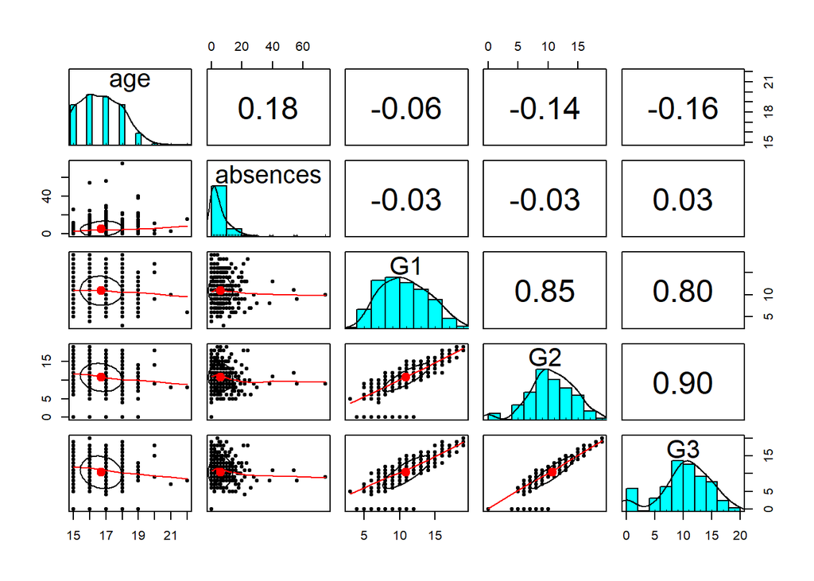

```r
pairs.panels(df[c('age','absences','G1','G2','G3')])
```

## Q2:

Using spread function to make dummy variables took from this website:https://www.r-bloggers.com/2021/10/convert-categorical-variable-to-numeric-in-r/#:~:text=To%20convert%20category%20variables%20to,use%20the%20spread()%20method.&text=To%20do%20so%2C%20use%20the,in%20this%20case%20%E2%80%9Cdummy%E2%80%9D)%3B.

This method is very simple and robust, the reason column was spread into four columns with ones, empty values were filled by zeros. Use new dataset for multi-regression.

```r
df_reasondymmy <- df %>% mutate(dummy = 1) %>%
  spread(key = reason, value = dummy, fill = 0) %>%
  mutate(dummy = 1) %>%
  spread(key = school, value = dummy, fill = 0)
g3_model1 <- lm(G3 ~ age+MS+studytime+G1+G2+course+other+home, data = df_reasondymmy)
summary(g3_model1)
```

```
##
## Call:
## lm(formula = G3 ~ age + MS + studytime + G1 + G2 + course + other +
##     home, data = df_reasondymmy)
##
## Residuals:
##     Min      1Q  Median      3Q     Max
## -9.1790 -0.4218  0.2648  0.9820  3.3826
##
## Coefficients:
##             Estimate Std. Error t value Pr(>|t|)
## (Intercept)  1.26486    1.47311   0.859  0.39108
## age         -0.15650    0.08385  -1.866  0.06275 .
## MS           0.16370    0.33360   0.491  0.62391
## studytime   -0.17327    0.12016  -1.442  0.15013
## G1           0.17200    0.05689   3.023  0.00267 **
## G2           0.96840    0.05061  19.134  < 2e-16 ***
## course      -0.19182    0.25384  -0.756  0.45032
## other        0.06337    0.38502   0.165  0.86936
## home        -0.32623    0.26786  -1.218  0.22401
## ---
## Signif. codes:  0 '***' 0.001 '**' 0.01 '*' 0.05 '.' 0.1 ' ' 1
##
## Residual standard error: 1.933 on 386 degrees of freedom
## Multiple R-squared:  0.8256, Adjusted R-squared:  0.822
## F-statistic: 228.5 on 8 and 386 DF,  p-value: < 2.2e-16
```

I chose age, school, studytime, G1 and G2 as inputs. These are typical criterion for hard working except age, since I just want to test how age behaves comparing with other significant factors.

## Q3:

I use step function with backward direction to eliminate unimportant factors determined by AIC. The smaller the AIC, the better the prediction. People always say AIC and BIC are generally two main concretion for elimination. check here:https://stats.stackexchange.com/questions/9171/aic-or-p-value-which-one-to-choose-for-model-selection

1. In turns out, four reasons have no significant impact on G3.
2. At last, only age, studytime, G1 and G2 are four main factors.

```r
step(g3_model1, direction='backward', trace = 1)
```

```
## Start:  AIC=529.5
## G3 ~ age + MS + studytime + G1 + G2 + course + other + home
##
##             Df Sum of Sq    RSS    AIC
## - other      1      0.10 1442.2 527.53
## - MS         1      0.90 1443.0 527.75
## - course     1      2.13 1444.2 528.09
## - home       1      5.54 1447.6 529.02
## <none>                   1442.1 529.50
## - studytime  1      7.77 1449.8 529.62
## - age        1     13.01 1455.1 531.05
## - G1         1     34.15 1476.2 536.75
## - G2         1   1367.80 2809.9 790.99
##
## Step:  AIC=527.53
## G3 ~ age + MS + studytime + G1 + G2 + course + home
##
##             Df Sum of Sq    RSS    AIC
## - MS         1      1.01 1443.2 525.81
## - course     1      3.03 1445.2 526.36
## - home       1      7.16 1449.3 527.49
## <none>                   1442.2 527.53
## - studytime  1      8.25 1450.4 527.78
## - age        1     13.04 1455.2 529.09
## - G1         1     34.07 1476.2 534.75
## - G2         1   1378.58 2820.8 790.52
##
## Step:  AIC=525.81
## G3 ~ age + studytime + G1 + G2 + course + home
##
##             Df Sum of Sq    RSS    AIC
## - course     1      2.85 1446.0 524.59
## - home       1      7.23 1450.4 525.78
## <none>                   1443.2 525.81
## - studytime  1      8.87 1452.0 526.23
## - age        1     12.18 1455.3 527.13
## - G1         1     34.00 1477.2 533.01
## - G2         1   1380.38 2823.6 788.91
##
## Step:  AIC=524.59
## G3 ~ age + studytime + G1 + G2 + home
##
##             Df Sum of Sq    RSS    AIC
## - home       1      4.60 1450.6 523.84
## <none>                   1446.0 524.59
## - studytime  1      8.02 1454.0 524.77
## - age        1     12.00 1458.0 525.85
## - G1         1     33.32 1479.3 531.59
## - G2         1   1402.68 2848.7 790.41
##
## Step:  AIC=523.84
## G3 ~ age + studytime + G1 + G2
##
##             Df Sum of Sq    RSS    AIC
## <none>                   1450.6 523.84
## - studytime  1      7.58 1458.2 523.90
## - age        1     12.37 1463.0 525.20
## - G1         1     34.37 1485.0 531.09
## - G2         1   1398.46 2849.1 788.47
```

```
##
## Call:
## lm(formula = G3 ~ age + studytime + G1 + G2, data = df_reasondymmy)
##
## Coefficients:
## (Intercept)          age    studytime           G1           G2
##      0.8351      -0.1412      -0.1674       0.1717       0.9712
```

```r
g3_model1_new <- lm(formula = G3 ~ age + studytime + G1 + G2, data = df_reasondymmy)
summary(g3_model1_new)
```

```
##
## Call:
## lm(formula = G3 ~ age + studytime + G1 + G2, data = df_reasondymmy)
##
## Residuals:
##     Min      1Q  Median      3Q     Max
## -9.3876 -0.3566  0.3055  1.0174  3.3072
##
## Coefficients:
##             Estimate Std. Error t value Pr(>|t|)
## (Intercept)  0.83510    1.36858   0.610  0.54209
## age         -0.14121    0.07743  -1.824  0.06896 .
## studytime   -0.16745    0.11730  -1.428  0.15423
## G1           0.17173    0.05650   3.040  0.00253 **
## G2           0.97119    0.05009  19.390  < 2e-16 ***
## ---
## Signif. codes:  0 '***' 0.001 '**' 0.01 '*' 0.05 '.' 0.1 ' ' 1
##
## Residual standard error: 1.929 on 390 degrees of freedom
## Multiple R-squared:  0.8246, Adjusted R-squared:  0.8228
## F-statistic: 458.3 on 4 and 390 DF,  p-value: < 2.2e-16
```

P-values are relatively small for two of four variables, age ~ 6^, while studytime is 15% insignificant(not sure if p value means this way). These four are considerables among all input variables.

## Q4:

```r
# age = 22, absences = 10, G1 = 18, G2 =
new_obs <- data.frame(age = 22, studytime=10,G1=15,G2=17)
augment(g3_model1_new, newdata = new_obs)
```

| age | studytime | G1 | G2 | .fitted |
| --- | --- | --- | --- | --- |
| 22 | 10 | 15 | 17 | 15.14014 |

```r
predict(g3_model1_new, newdata = new_obs)
```

```
##        1
## 15.14014
```

## Q5:

```r
sqrt(sum((g3_model1_new$fitted.values - df$G3)^2)/nrow(df))
```

```
## [1] 1.916369
```

Amazingly similar RMSE as Chris’ work with different variables, lol. What do you think Chris?

# Problem 2:

## Q1:

Data processing, relatively redundant but I don’t want to edit them, sorry :(.

```r
df1 <- df
df2 <- df1 %>%
  mutate(PF = ifelse(G3<10, "F", "P")) %>%
  mutate(PFdummy = ifelse(PF == 'F',0,1))
```

## Q2:

Parallel regressions are exhibited since Fjob is actually a categorical variable.

```r
step(glm( PFdummy ~ -G3 -PF, data = df2, family = binomial), direction = 'backward', trace = 0)
```

```
##
## Call:  glm(formula = PFdummy ~ -G3 - PF, family = binomial, data = df2)
##
## Coefficients:
## (Intercept)
##      0.7122
##
## Degrees of Freedom: 394 Total (i.e. Null);  394 Residual
## Null Deviance:       500.5
## Residual Deviance: 500.5     AIC: 502.5
```

```r
g3_glm <- glm(formula = PFdummy ~ school + age + Fjob + studytime + G2, family = binomial, data = df2)

g3_glm
```

```
##
## Call:  glm(formula = PFdummy ~ school + age + Fjob + studytime + G2,
##     family = binomial, data = df2)
##
## Coefficients:
##  (Intercept)      schoolMS           age    Fjobhealth     Fjobother
##     -12.1355        1.9859       -0.5905        1.3106        3.2953
## Fjobservices   Fjobteacher     studytime            G2
##       1.3302        2.6817       -0.7459        2.2982
##
## Degrees of Freedom: 394 Total (i.e. Null);  386 Residual
## Null Deviance:       500.5
## Residual Deviance: 118   AIC: 136
```

## Q3:

Parallel regressions are exhibited since Fjob is actually a categorical variable.

schoolMS means school MS has 1.9859 higher than GP with others identical.

## Q4:

```r
sqrt(sum((predict(g3_glm) - df2$G3)^2)/ nrow(df2))
```

```
## [1] 8.306289
```

# Problem 3:

## Q1:

```r
wine <- read_csv("https://da5030.weebly.com/uploads/8/6/5/9/8659576/whitewines.csv")
str(wine)
wine_train <- wine[1:3750, ]
wine_test <- wine[3751:4898, ]
m.rpart <- rpart(quality ~ ., data = wine_train)
```

rpart.plot can plot regression tree in a flow chart. At first node, 2/3 contains alcohol smaller than 10.9.

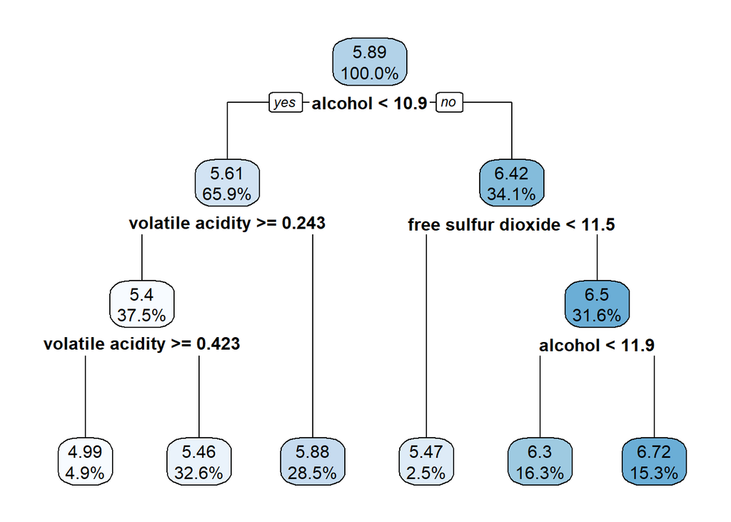

```r
rpart.plot(m.rpart, digits = 3)
```

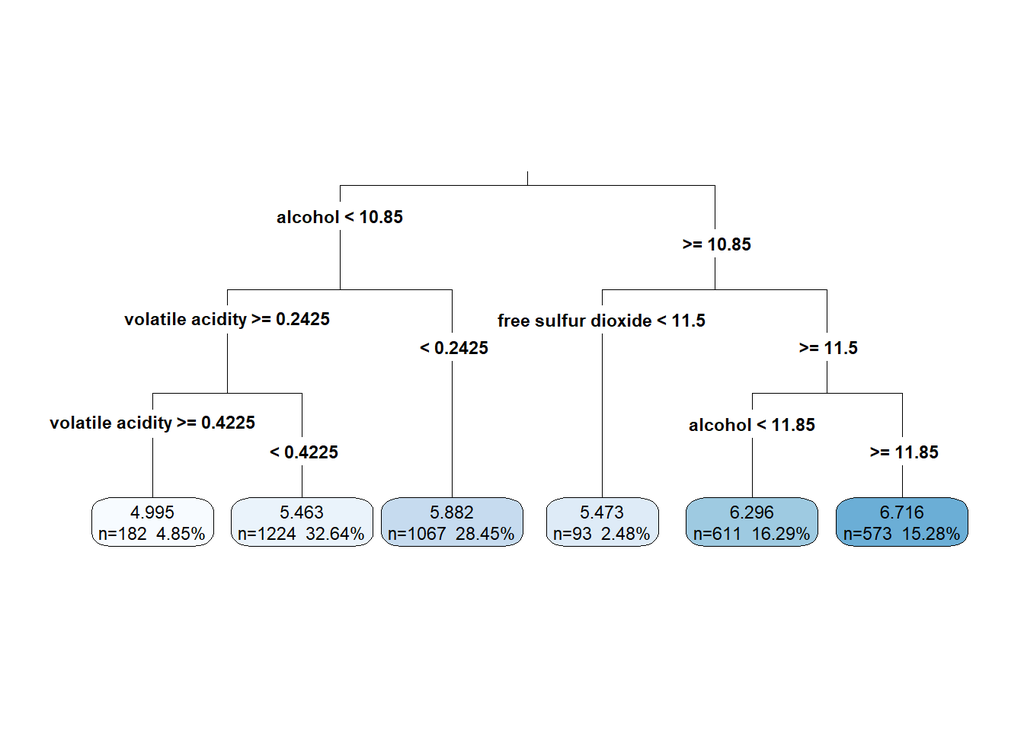

```r
rpart.plot(m.rpart, digits = 4, fallen.leaves = TRUE,
               type = 3, extra = 101)
```

```r
p.rpart <- predict(m.rpart, wine_test)
summary(p.rpart)
```

```
##    Min. 1st Qu.  Median    Mean 3rd Qu.    Max.
##   4.995   5.463   5.882   5.999   6.296   6.716
```

```r
summary(wine_test$quality)
```

```
##    Min. 1st Qu.  Median    Mean 3rd Qu.    Max.
##   3.000   5.000   6.000   5.848   6.000   8.000
```

```r
cor(p.rpart, wine_test$quality)
```

```
## [1] 0.4931608
```

MAE is a way to determine the error of prediction. It doesn’t give the same results as RMSE.

```r
MAE <- function(actual, predicted) {
    mean(abs(actual - predicted))
}
MAE(p.rpart, wine_test$quality)
```

```
## [1] 0.5732104
```

```r
mean(wine_train$quality)
```

```
## [1] 5.886933
```

```r
MAE(5.87, wine_test$quality)
```

```
## [1] 0.5815679
```

model tree function in cubist package can make linear regression on each leaf of a regression tree. Therefore, regression tree is actually a Decision Tree can take continuous variable as input, while Model Tree is an actual “Regression Tree”.

```r
library(Cubist)
m.cubist <- cubist(x = wine_train[-12], y = wine_train$quality)
m.cubist
```

```
##
## Call:
## cubist.default(x = wine_train[-12], y = wine_train$quality)
##
## Number of samples: 3750
## Number of predictors: 11
##
## Number of committees: 1
## Number of rules: 10
```

```r
summary(m.cubist)
```

```
##
## Call:
## cubist.default(x = wine_train[-12], y = wine_train$quality)
##
##
## Cubist [Release 2.07 GPL Edition]  Fri Mar 11 22:17:29 2022
## ---------------------------------
##
##     Target attribute `outcome'
##
## Read 3750 cases (12 attributes) from undefined.data
##
## Model:
##
##   Rule 1: [918 cases, mean 5.3, range 3 to 7, est err 0.5]
##
##     if
##  volatile acidity > 0.26
##  alcohol <= 10.2
##     then
##  outcome = 66.6 + 0.187 alcohol + 0.041 residual sugar - 65 density
##            - 1.38 volatile acidity + 0.5 pH + 0.0028 free sulfur dioxide
##
##   Rule 2: [177 cases, mean 5.5, range 4 to 8, est err 0.5]
##
##     if
##  citric acid > 0.42
##  residual sugar <= 14.05
##  free sulfur dioxide > 49
##     then
##  outcome = 32.5 + 0.379 alcohol - 0.024 residual sugar - 31 density
##            - 0.54 volatile acidity + 0.15 sulphates
##            + 0.0003 total sulfur dioxide + 0.07 pH + 0.4 chlorides
##            + 0.01 fixed acidity
##
##   Rule 3: [490 cases, mean 5.7, range 3 to 8, est err 0.5]
##
##     if
##  volatile acidity <= 0.26
##  residual sugar <= 12.75
```

[output cut: 98 more lines]

```
##
##     85%    99%    alcohol
##     73%    84%    free sulfur dioxide
##     40%    97%    volatile acidity
##     33%    99%    residual sugar
##     15%    11%    citric acid
##      5%    62%    fixed acidity
##            98%    density
##            85%    pH
##            66%    sulphates
##            21%    total sulfur dioxide
##             8%    chlorides
##
##
## Time: 0.2 secs
```

```r
p.cubist <- predict(m.cubist, wine_test)
summary(p.cubist)
```

```
##    Min. 1st Qu.  Median    Mean 3rd Qu.    Max.
##   3.315   5.574   6.093   6.028   6.437   7.647
```

```r
cor(p.cubist, wine_test$quality)
```

```
## [1] 0.5683117
```

```r
MAE(wine_test$quality, p.cubist)
```

```
## [1] 0.5306253
```

## Q2:

And RMSE of model tree is smaller than regression tree, which indicates model tree did a better job.

```r
sqrt(sum((p.cubist - wine_test$quality)^2)/ nrow(df2))
```

```
## [1] 1.172098
```

```r
sqrt(sum((p.rpart - wine_test$quality)^2)/ nrow(df2))
```

```
## [1] 1.203101
```